# Pets In Mexico Analysis

Jose Juan Lopez

2024-03-05

## Setting up my environment

Load libraries.

```r
library(tidyverse)
```

```r
library(dplyr)
library(ggplot2)
library(tidyr)
library(knitr)
library(skimr)
library(janitor)
library(readr)
library(grid)
library(plotly)
library(magrittr)
library(RColorBrewer)
library(scales)
library(tibble)
library(maps)
library(sf)
library(rnaturalearth)
```

## Read documents

In this analysis I choose to analyze:

- Mascotas_Hogar_2021_12_08.csv
- Mascotas_Población_2021_12_08.csv
- Mascotas_Tipo_2021_12_08.csv

I want to conduct this analysis because I have a fondness for animals, although to be completely honest, I have a stronger preference for cats as they are more independent in my opinion. Regarding the topic at hand, I would like to learn about the **number** of animals present throughout Mexican territory, as well as the most **favored** pet among Mexicans.

### Showing house pet data

```r
dHouse <- read.csv('~/Documents/Data Analyst/PetsInMexico/Inegi/Mascotas_Hogar_2021_12_08.csv')
head(dHouse)
```

```
##               Entidad Con.mascota Sin.mascota   Total
## 1      Aguascalientes      275117      139195  414312
## 2     Baja California      833462      435688 1269150
## 3 Baja California Sur      185140       99808  284948
## 4            Campeche      210501       65525  276026
## 5            Coahuila      641655      318452  960107
## 6              Colima      164655       92234  256889
```

### Showing data about pet ownership

```r
dOwnership <- read.csv('~/Documents/Data Analyst/PetsInMexico/Inegi/Mascotas_Población_2021_12_08.csv')
head(dOwnership)
```

```
##               Entidad Con.mascota Sin.mascota   Total
## 1      Aguascalientes      710007      318834 1028841
## 2     Baja California     1937278      900513 2837791
## 3 Baja California Sur      440107      199801  639908
## 4            Campeche      527186      138753  665939
## 5            Coahuila     1636869      700690 2337559
## 6              Colima      377968      179105  557073
```

### Showing data about types of pets (ex. hamsters, birds, fishes, etc.)

```r
dTypes <- read.csv('~/Documents/Data Analyst/PetsInMexico/Inegi/Mascotas_Tipo_2021_12_08.csv')
head(dTypes)
```

```
##               Entidad   Perro   Gato Otra.Especie   Total
## 1      Aguascalientes  469627 145445       440209 1055281
## 2     Baja California 1506073 674662       671873 2852608
## 3 Baja California Sur  343590 148293       188203  680086
## 4            Campeche  421802 161582       216301  799685
## 5            Coahuila 1108456 378605       756377 2243438
## 6              Colima  258895 119132       287411  665438
```

## Searching duplicate data

After to showing pets activity, I inspected the data to check if duplicate data exists

### Pets data

```r
PH <- dHouse %>%
  get_dupes(Entidad)
```

```
## No duplicate combinations found of: Entidad
```

```r
  head(PH)
```

```
## [1] Entidad     dupe_count  Con.mascota Sin.mascota Total
## <0 rows> (or 0-length row.names)
```

```r
PO <- dOwnership %>%
  get_dupes(Entidad)
```

```
## No duplicate combinations found of: Entidad
```

```r
  head(PO)
```

```
## [1] Entidad     dupe_count  Con.mascota Sin.mascota Total
## <0 rows> (or 0-length row.names)
```

```r
PT <- dTypes %>%
  get_dupes(Entidad)
```

```
## No duplicate combinations found of: Entidad
```

```r
  head(PT)
```

```
## [1] Entidad      dupe_count   Perro        Gato         Otra.Especie
## [6] Total
## <0 rows> (or 0-length row.names)
```

Once the search for duplicated information in the files was completed, no duplicate data was found.

Afterwards, we will review the totals of pets and the types of pets that exist within Mexican territory

```r
total_sum_h <- colSums(select(dHouse, Con.mascota, Sin.mascota))
total_sum_table_h <- data.frame(Column = names(total_sum_h), Total = total_sum_h)
total_sum_table_h$Column <- c("With pet", "Non pet")

table1 <- kable(total_sum_table_h, caption = "Total number of pets per household in Mexico")
print(table1)
```

```
##
##
## Table: Total number of pets per household in Mexico
##
## |            |Column   |    Total|
## |:-----------|:--------|--------:|
## |Con.mascota |With pet | 26508923|
## |Sin.mascota |Non pet  | 11909487|
```

```r
total_sum_p <- colSums(select(dOwnership, Con.mascota, Sin.mascota))
total_sum_table_p <- data.frame(Column = names(total_sum_p), Total = total_sum_p)
total_sum_table_p$Column <- c("With pet", "Non pet")

table2 <- kable(total_sum_table_p, caption = "Total number of pets per mexican population")
print(table2)
```

```
##
##
## Table: Total number of pets per mexican population
##
## |            |Column   |    Total|
## |:-----------|:--------|--------:|
## |Con.mascota |With pet | 66159188|
## |Sin.mascota |Non pet  | 24897273|
```

```r
total_sum_t <- colSums(select(dTypes, Perro, Gato, Otra.Especie))
total_sum_table_t <- data.frame(Column = names(total_sum_t), Total = total_sum_t)
total_sum_table_t$Column <- c("Dog", "Cat", "Other Pet")

table2 <- kable(total_sum_table_t, caption = "Total of pets in Mexico")
print(table2)
```

```
##
##
## Table: Total of pets in Mexico
##
## |             |Column    |    Total|
## |:------------|:---------|--------:|
## |Perro        |Dog       | 47711365|
## |Gato         |Cat       | 18986535|
## |Otra.Especie |Other Pet | 24617509|
```

Total of pets in Mexico is obtained

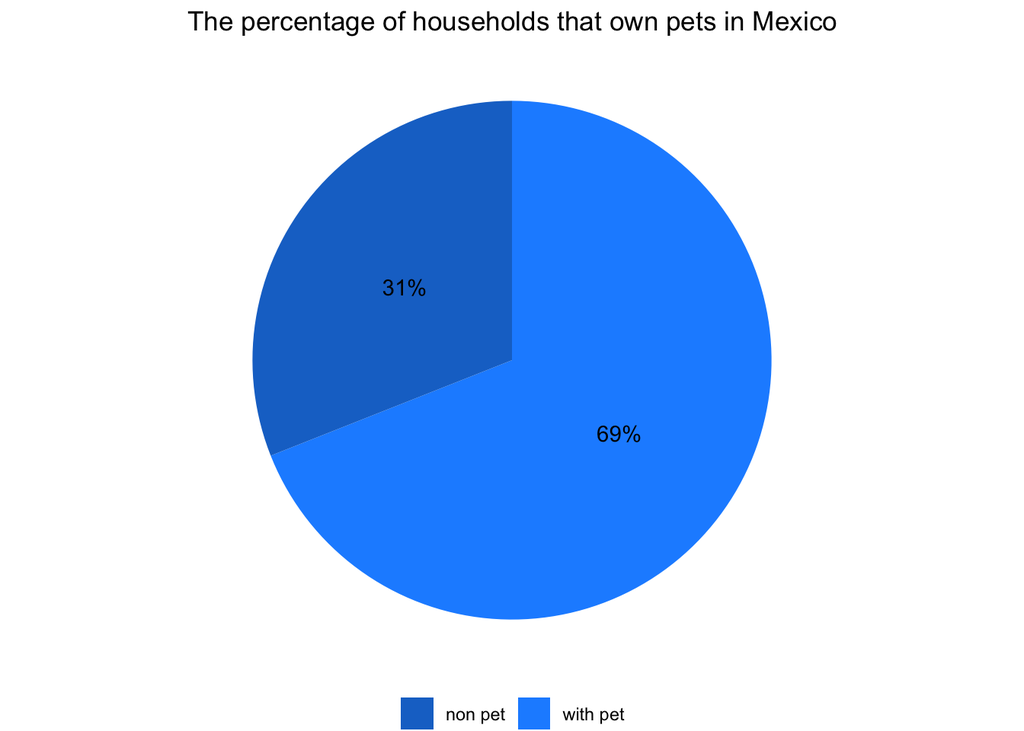

```r
sum_with_pet_h <- sum(dHouse$Con.mascota)
sum_non_pet_h <- sum(dHouse$Sin.mascota)

porcentage_with_pet_h <- sum_with_pet_h / sum(sum_with_pet_h, sum_non_pet_h) * 100
porcentage_non_pet_h <- sum_non_pet_h / sum(sum_with_pet_h, sum_non_pet_h) * 100
total_dHouse <- data.frame(
  Category_h = c("with pet", "non pet"),
  Value_h = c(sum_with_pet_h, sum_non_pet_h),
  Porcentage_h = c(porcentage_with_pet_h, porcentage_non_pet_h)
)

dark_blue <- "dodgerblue3"
light_blue <- "dodgerblue"

ggplot(total_dHouse, aes(x = "", y = Value_h, fill = Category_h)) +
  geom_bar(stat = "identity", width = 1) +
  coord_polar(theta = "y") +
  geom_text(aes(label = paste0(round(Porcentage_h, 1), "%")),
            position = position_stack(vjust = 0.5)) +
  labs(title = "The percentage of households that own pets in Mexico",
       fill = NULL, x = NULL, y = NULL) +
  scale_fill_manual(values = c(dark_blue, light_blue)) +
  theme_void() +
  theme(legend.position = "bottom")
```

The percentages of Mexican households that have pets and those that do not have pets are observed

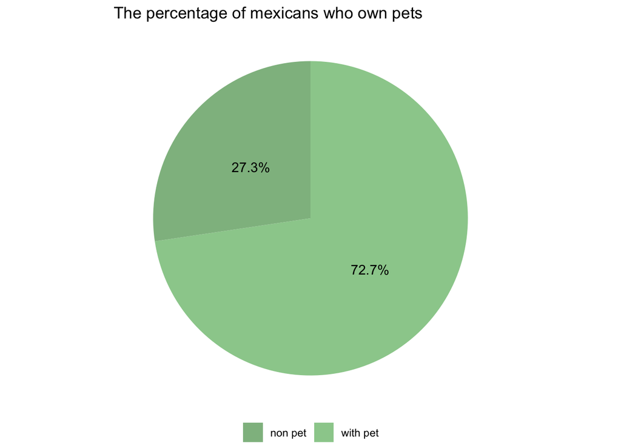

```r
sum_with_pet_p <- sum(dOwnership$Con.mascota)
sum_non_pet_p <- sum(dOwnership$Sin.mascota)

porcentage_with_pet_p <- sum_with_pet_p / sum(sum_with_pet_p, sum_non_pet_p) * 100
porcentage_non_pet_p <- sum_non_pet_p / sum(sum_with_pet_p, sum_non_pet_p) * 100
total_dOwnership <- data.frame(
  Category_p = c("with pet", "non pet"),
  Value_p = c(sum_with_pet_p, sum_non_pet_p),
  Porcentage_p = c(porcentage_with_pet_p, porcentage_non_pet_p)
)

dark_green <- "darkseagreen"
light_green <- "darkseagreen3"

ggplot(total_dOwnership, aes(x = "", y = Value_p, fill = Category_p)) +
  geom_bar(stat = "identity", width = 1) +
  coord_polar(theta = "y") +
  geom_text(aes(label = paste0(round(Porcentage_p, 1), "%")),
            position = position_stack(vjust = 0.5)) +
  labs(title = "The percentage of mexicans who own pets",
       fill = NULL, x = NULL, y = NULL) +
  scale_fill_manual(values = c(dark_green, light_green)) +
  theme_void() +
  theme(legend.position = "bottom")
```

The percentages of mexican population that have pets and those that do not have pets are observed

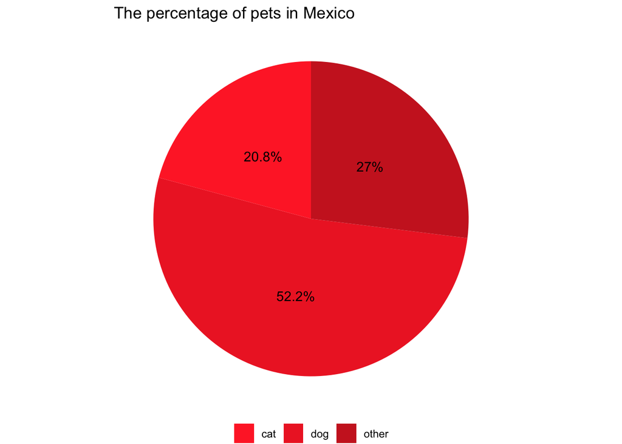

```r
sum_dog <- sum(dTypes$Perro)
sum_cat <- sum(dTypes$Gato)
sum_other <- sum(dTypes$Otra.Especie)

total_sum <- sum(sum_cat, sum_dog, sum_other)

porcentage_cat <- sum_cat / total_sum * 100
porcentage_dog <- sum_dog / total_sum * 100
porcentage_other <- sum_other / total_sum * 100

total_dTypes <- data.frame(
  Category_t = c("dog", "cat", "other"),
  Value_t = c(sum_dog, sum_cat, sum_other),
  Porcentage_t = c(porcentage_dog, porcentage_cat, porcentage_other)
)

dark_red <- "firebrick1"
neutro_red <- "firebrick2"
light_red <- "firebrick3"

ggplot(total_dTypes, aes(x = "", y = Value_t, fill = Category_t)) +
  geom_bar(stat = "identity", width = 1) +
  coord_polar(theta = "y") +
  geom_text(aes(label = paste0(round(Porcentage_t, 1), "%")),
            position = position_stack(vjust = 0.5)) +
  labs(title = "The percentage of pets in Mexico",
       fill = NULL, x = NULL, y = NULL) +
  scale_fill_manual(values = c(dark_red, neutro_red, light_red)) +
  theme_void() +
  theme(legend.position = "bottom")
```

The percentages of dogs, cats, and other pets (hamsters, birds, fishes, etc.) inhabiting Mexico are examined

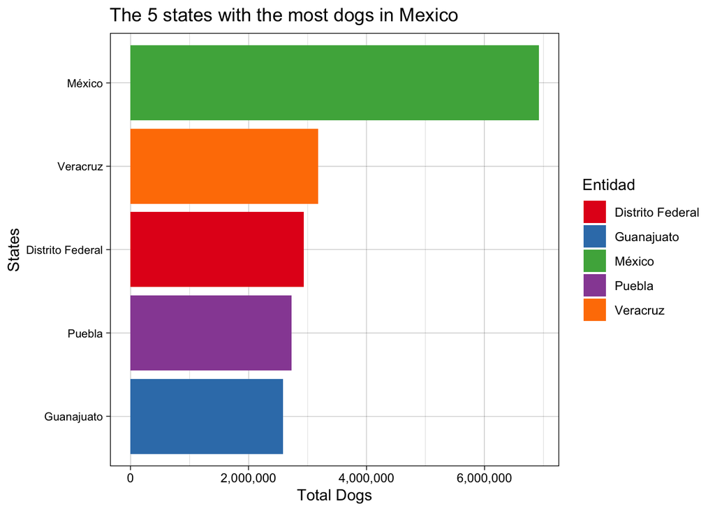

```r
resume <- dTypes %>%
  group_by(Entidad) %>%
  summarize(total = sum(Perro)) %>%
  arrange(desc(total)) %>%
  slice(1:5)

dogs_chart <- ggplot(resume, aes(x = total, y = reorder(Entidad, total), fill = Entidad)) +
  geom_bar(stat = "identity") +
  labs(title = "The 5 states with the most dogs in Mexico", x= "Total Dogs", y = "States") +
  theme_linedraw() +
  theme(axis.text.y = element_text(size = 8, angle = 0)) +
  scale_x_continuous(labels = scales::comma) +
  scale_fill_brewer(palette = "Set1")

dogs_table_m <- as_tibble(resume)
print(dogs_chart)
```

```r
print(dogs_table_m)
```

```
## # A tibble: 5 × 2
##   Entidad            total
##   <chr>              <int>
## 1 México           6919036
## 2 Veracruz         3176730
## 3 Distrito Federal 2932109
## 4 Puebla           2729657
## 5 Guanajuato       2586713
```

The 5 states with the most dogs in Mexico are shown

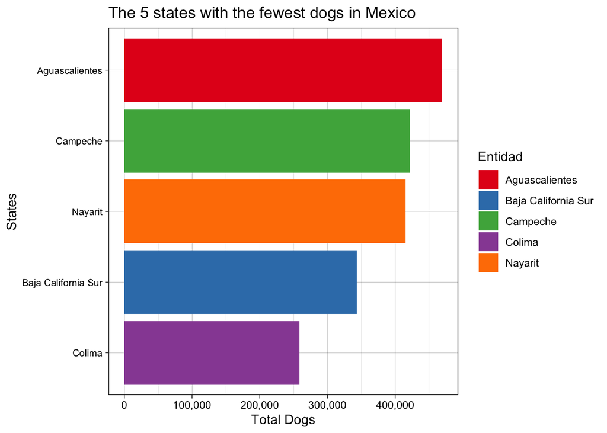

```r
resume <- dTypes %>%
  group_by(Entidad) %>%
  summarize(total = sum(Perro)) %>%
  arrange(total) %>%
  slice(1:5)

dogs_chart <- ggplot(resume, aes(x = total, y = reorder(Entidad, total), fill = Entidad)) +
  geom_bar(stat = "identity") +
  labs(title = "The 5 states with the fewest dogs in Mexico", x= "Total Dogs", y = "States") +
  theme_linedraw() +
  theme(axis.text.y = element_text(size = 8, angle = 0)) +
  scale_x_continuous(labels = scales::comma) +
  scale_fill_brewer(palette = "Set1")

dogs_table_f <- as_tibble(resume)
dogs_table_f <- dogs_table_f %>%
  arrange(desc(total))

print(dogs_chart)
```

```r
print(dogs_table_f)
```

```
## # A tibble: 5 × 2
##   Entidad              total
##   <chr>                <int>
## 1 Aguascalientes      469627
## 2 Campeche            421802
## 3 Nayarit             415563
## 4 Baja California Sur 343590
## 5 Colima              258895
```

The 5 states with the fewest dogs in Mexico are shown

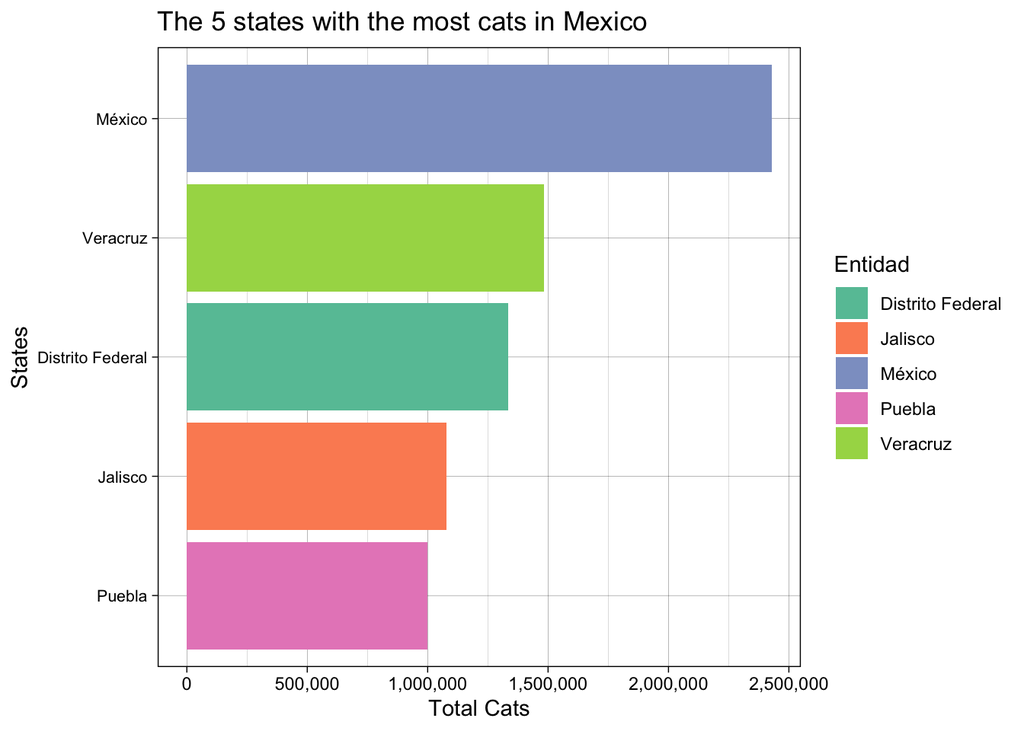

```r
resume <- dTypes %>%
  group_by(Entidad) %>%
  summarize(total = sum(Gato)) %>%
  arrange(desc(total)) %>%
  slice(1:5)

cats_chart <- ggplot(resume, aes(x = total, y = reorder(Entidad, total), fill = Entidad)) +
  geom_bar(stat = "identity") +
  labs(title = "The 5 states with the most cats in Mexico", x= "Total Cats", y = "States") +
  theme_linedraw() +
  theme(axis.text.y = element_text(size = 8, angle = 0)) +
  scale_x_continuous(labels = scales::comma) +
  scale_fill_brewer(palette = "Set2")

cats_table_m <- as_tibble(resume)
print(cats_chart)
```

```r
print(cats_table_m)
```

```
## # A tibble: 5 × 2
##   Entidad            total
##   <chr>              <int>
## 1 México           2428373
## 2 Veracruz         1483856
## 3 Distrito Federal 1333369
## 4 Jalisco          1079193
## 5 Puebla            999402
```

The 5 states with the most cats in Mexico are shown

[figure not shown]

```r
resume <- dTypes %>%
  group_by(Entidad) %>%
  summarize(total = sum(Perro)) %>%
  arrange(total) %>%
  slice(1:5)

cats_chart <- ggplot(resume, aes(x = total, y = reorder(Entidad, total), fill = Entidad)) +
  geom_bar(stat = "identity") +
  labs(title = "The 5 states with the fewest cats in Mexico", x= "Total Cats", y = "States") +
  theme_linedraw() +
  theme(axis.text.y = element_text(size = 8, angle = 0)) +
  scale_x_continuous(labels = scales::comma) +
  scale_fill_brewer(palette = "Set2")

cats_table_f <- as_tibble(resume)
cats_table_f <- cats_table_f %>%
  arrange(desc(total))

print(cats_chart)
```

```r
print(cats_table_f)
```

[output not shown]

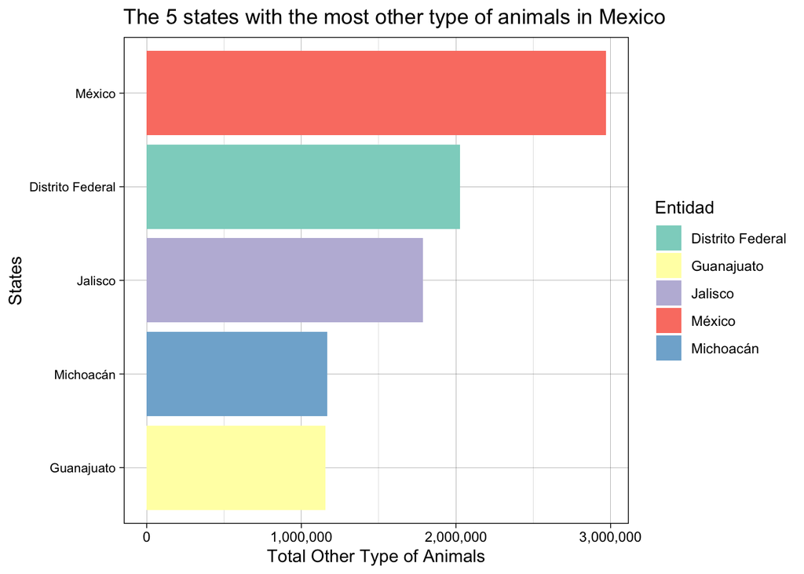

```r
resume <- dTypes %>%
  group_by(Entidad) %>%
  summarize(total = sum(Otra.Especie)) %>%
  arrange(desc(total)) %>%
  slice(1:5)

other_a_chart <- ggplot(resume, aes(x = total, y = reorder(Entidad, total), fill = Entidad)) +
  geom_bar(stat = "identity") +
  labs(title = "The 5 states with the most other type of animals in Mexico", x= "Total Other Type of Animals", y = "States") +
  theme_linedraw() +
  theme(axis.text.y = element_text(size = 8, angle = 0)) +
  scale_x_continuous(labels = scales::comma) +
  scale_fill_brewer(palette = "Set3")

other_a_table_m <- as_tibble(resume)
print(other_a_chart)
```

```r
print(other_a_table_m)
```

```
## # A tibble: 5 × 2
##   Entidad            total
##   <chr>              <int>
## 1 México           2969425
## 2 Distrito Federal 2026476
## 3 Jalisco          1785147
## 4 Michoacán        1168286
## 5 Guanajuato       1156618
```

The 5 states with the most other type of animals (hamsters, birds, fishes, etc.) in Mexico are shown

[figure not shown]

```r
resume <- dTypes %>%
  group_by(Entidad) %>%
  summarize(total = sum(Otra.Especie)) %>%
  arrange(total) %>%
  slice(1:5)

other_a_chart <- ggplot(resume, aes(x = total, y = reorder(Entidad, total), fill = Entidad)) +
  geom_bar(stat = "identity") +
  labs(title = "The 5 states with the fewest cats in Mexico", x= "Total Cats", y = "States") +
  theme_linedraw() +
  theme(axis.text.y = element_text(size = 8, angle = 0)) +
  scale_x_continuous(labels = scales::comma) +
  scale_fill_brewer(palette = "Set3")

other_a_chart_f <- as_tibble(resume)
other_a_chart_f <- other_a_chart_f %>%
  arrange(desc(total))

print(other_a_chart)
```

```r
print(other_a_chart_f)
```

```
## # A tibble: 5 × 2
##   Entidad              total
##   <chr>                <int>
## 1 Nayarit             331083
## 2 Colima              287411
## 3 Tlaxcala            275664
## 4 Campeche            216301
## 5 Baja California Sur 188203
```

The 5 states with the fewest other type of animals (hamsters, birds, fishes, etc.) in Mexico are shown

From what we know, cats and dogs are the most preferred animals by humans worldwide, so I took it upon myself to see if they were also popular here in Mexico or if people preferred other types of pets

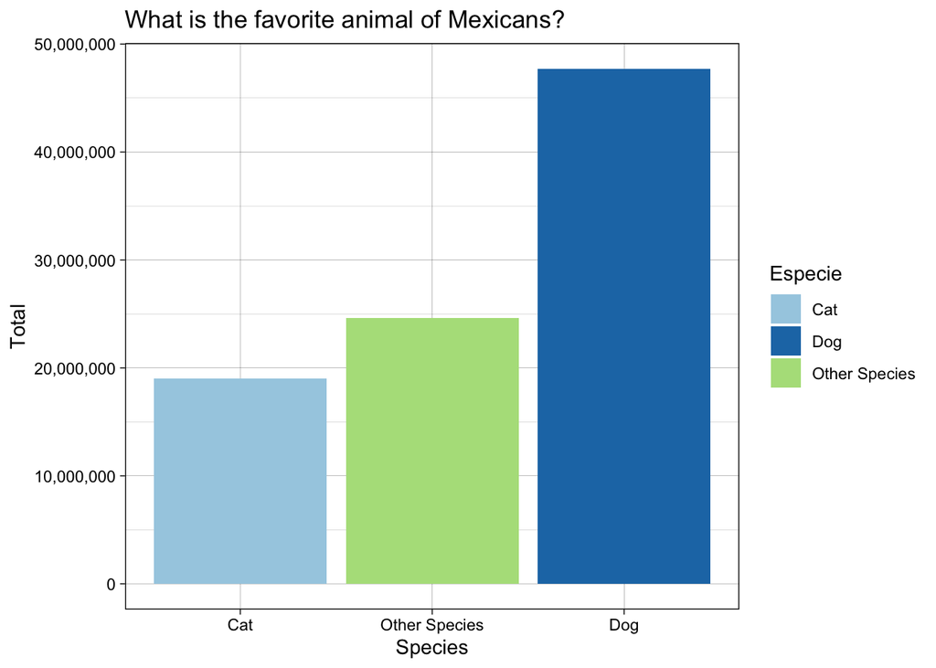

```r
total_each_animals <- colSums(dTypes[, c("Perro", "Gato", "Otra.Especie")])

total_ea <- data.frame(
  Especie = names(total_each_animals),
  Total = total_each_animals
)

total_ea$Especie <- gsub("Perro", "Dog", total_ea$Especie)
total_ea$Especie <- gsub("Gato", "Cat", total_ea$Especie)
total_ea$Especie <- gsub("Otra.Especie", "Other Species", total_ea$Especie)

total_ea <- total_ea %>%
  arrange(desc(Total))

chart_vs <- ggplot(total_ea, aes(x = reorder(Especie, Total), y = Total, fill = Especie)) +
  geom_bar(stat = "identity") +
  labs(x = "Species", y = "Total", title = "What is the favorite animal of Mexicans?") +
  scale_fill_brewer(palette = "Paired") +
  theme_linedraw()

chart_vs +
  scale_y_continuous(labels = scales::comma)
```

```r
total_ea
```

```
##                    Especie    Total
## Perro                  Dog 47711365
## Otra.Especie Other Species 24617509
## Gato                   Cat 18986535
```

In the results, we can observe that the favorite animal of Mexicans is the dog, and the one that is not as favored is the cat

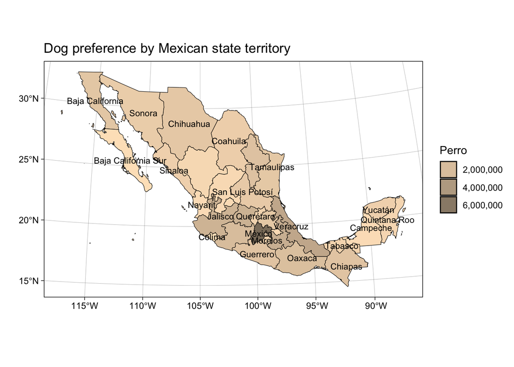

```r
country_mx <- ne_states(country = "mexico", returnclass = "sf")

country_mx <- st_transform(country_mx, crs = "+proj=utm +zone=13 +datum=WGS84")

dTypes_sorted <- dTypes[match(country_mx$name, dTypes$Entidad), ]

mx_data <- merge(country_mx, dTypes_sorted, by.x = "name", by.y = "Entidad", all.x = TRUE)

ggplot() +
  geom_sf(data = mx_data, aes(fill = Perro), color = "black") +
  geom_sf_text(data = country_mx, aes(label = name), size = 3, color = "black", check_overlap = TRUE, na.rm = TRUE) +
  scale_fill_gradient(low = "bisque1", high = "bisque4", guide = "legend", name = "Perro", labels = scales::comma) +
  labs(title = "Dog preference by Mexican state territory", x = "", y = "") +
  theme_linedraw()
```

```r
dTypes_sorted <- dTypes_sorted %>% arrange(desc(Perro))

fd_chart <- data.frame(Entidad = dTypes_sorted$Entidad, Perro = dTypes_sorted$Perro)

print(fd_chart)
```

```
##                Entidad   Perro
## 1               México 6919036
## 2             Veracruz 3176730
## 3     Distrito Federal 2932109
## 4               Puebla 2729657
## 5           Guanajuato 2586713
## 6              Jalisco 2494604
## 7            Michoacán 2000816
## 8               Oaxaca 1849569
## 9           Nuevo León 1719666
## 10             Chiapas 1596107
## 11            Guerrero 1595830
## 12     Baja California 1506073
## 13           Chihuahua 1416000
## 14          Tamaulipas 1395578
```

[output cut: 19 more lines]

Finally, Mexican states can be represented according to the density of canine population, using a color palette that ranges from those harboring a higher number of dogs, depicted in darker shades, to those with fewer dogs, represented in lighter tones.

## Conclusion

Lastly, although cats appear to occupy the last place in terms of preference, there is still a considerable population that chooses them as pets, indicating that there continues to be diversity in animal preferences among people in Mexico.

## References

I would like to thank the following websites that helped me with create my case:

- Kaggle [Click here](https://www.kaggle.com)
- INEGI [Click here](https://www.inegi.org.mx)
- Posit [Click here](https://support.posit.co/hc/en-us)
- Stack Overflow [Click here](https://stackoverflow.com)